# data-analysis-rep

#### Figure Analysis: Figure 1

For Dzogang et al. **Figure 1**, they look at the variation of word volume within the 24-hour cycle, with a 99% confidence interval. In order to achieve this, author’s averaged the hourly word volume. I then assume they calculated their 99% confidence intervals from student t-test. They have the y-axis representing that average volume per hour in the top 20,000 most frequent words across the 4 years. Although not labeled, the x-axis represents hours, starting at 6 AM in the morning.

- This figure includes descriptive and inferential statistics (99% confidence intervals)

```r
# Start by loading in libraries
library(tidyverse)
```

```r
library(dplyr)
library(ggplot2)
library(skimr)
library(reshape2)
library(zoo)
library(chron)
# Grab data
f <- "https://raw.githubusercontent.com/kierstenbell/data-analysis-rep/main/data/vol.csv"
d <- read.csv(f, sep = " ")
colnames(d) <- c("date", "time", "wordfreq") #creating column names to make data easier to work with

# Let's take a look out our data
head(d)
```

```
##         date     time wordfreq
## 1 01-01-2010 01:00:00    73937
## 2 01-01-2010 02:00:00    57242
## 3 01-01-2010 03:00:00    40424
## 4 01-01-2010 04:00:00    25363
## 5 01-01-2010 05:00:00    15636
## 6 01-01-2010 06:00:00    14015
```

```r
skim(d)
```

Data summary

| Name | d |
| --- | --- |
| Number of rows | 33575 |
| Number of columns | 3 |
| _______________________ |  |
| Column type frequency: |  |
| character | 2 |
| numeric | 1 |
| ________________________ |  |
| Group variables | None |

**Variable type: character**

| skim_variable | n_missing | complete_rate | min | max | empty | n_unique | whitespace |
| --- | --- | --- | --- | --- | --- | --- | --- |
| date | 0 | 1 | 10 | 10 | 0 | 1399 | 0 |
| time | 0 | 1 | 8 | 8 | 0 | 24 | 0 |

**Variable type: numeric**

| skim_variable | n_missing | complete_rate | mean | sd | p0 | p25 | p50 | p75 | p100 | hist |
| --- | --- | --- | --- | --- | --- | --- | --- | --- | --- | --- |
| wordfreq | 0 | 1 | 203054.4 | 141039.8 | 0 | 103076.5 | 189289 | 229626 | 781005 | ▇▇▂▁▁ |

```r
# There is date (01-01-2010 - 31-10-2014), time (00:00:00-midnight - 23:00:00-11 PM), and word frequency.
# To generate the figure, we will need to average each hour across all the days and generate 99% confidence intervals

# Get average words per hour (AvgFrequency) and generate 99% confidence intervals (alpha = 0.01)
alpha = 0.01

d.Avg <- summarize(.data = d,
                      AvgFrequency = mean(wordfreq),
                      lower_ci = mean(wordfreq) + qnorm(1 - (alpha/2))* sqrt(var(wordfreq)/length(wordfreq)), # lower 99% CI
                      upper_ci = mean(wordfreq) - qnorm(1 - (alpha/2))* sqrt(var(wordfreq)/length(wordfreq)), # upper 99% CI
                      .by = time)

# Author's plot starts at 6 (AM); current data will start at midnight.
# Mutate the data so that it can start at the same time (ie make 6 AM "01")
# There's probably a better way to do this but I'm creating the variable "x" so that 6 AM will be first on the chart, followed by 7 AM, until 5 AM is the last point on the graph. It is possible to shift the time using as.POSIXct (see Figure 2) but I cannot get it to work.
d.Avg <- d.Avg %>%
 mutate(x = case_when(time =="00:00:00" ~ "19",
                      time =="01:00:00" ~ "20",
                      time =="02:00:00" ~ "21",
                      time =="03:00:00" ~ "22",
                      time =="04:00:00" ~ "23",
                      time =="05:00:00" ~ "24",
                      time =="06:00:00" ~ "01",
                      time =="07:00:00" ~ "02",
                      time =="08:00:00" ~ "03",
                      time =="09:00:00" ~ "04",
                      time =="10:00:00" ~ "05",
                      time =="11:00:00" ~ "06",
                      time =="12:00:00" ~ "07",
                      time =="13:00:00" ~ "08",
                      time =="14:00:00" ~ "09",
                      time =="15:00:00" ~ "10",
                      time =="16:00:00" ~ "11",
                      time =="17:00:00" ~ "12",
                      time =="18:00:00" ~ "13",
                      time =="19:00:00" ~ "14",
                      time =="20:00:00" ~ "15",
                      time =="21:00:00" ~ "16",
                      time =="22:00:00" ~ "17",
                      time =="23:00:00" ~ "18"))
d.Avg
```

```
##        time AvgFrequency  lower_ci  upper_ci  x
## 1  01:00:00    151955.94 157693.50 146218.37 20
## 2  02:00:00    106070.14 110001.52 102138.76 21
## 3  03:00:00     78441.42  81420.51  75462.33 22
## 4  04:00:00     61876.48  64135.27  59617.69 23
## 5  05:00:00     56672.76  58695.20  54650.32 24
## 6  06:00:00     77351.74  80096.32  74607.16 01
## 7  07:00:00    136549.38 141848.19 131250.58 02
## 8  08:00:00    190169.59 197128.33 183210.85 03
## 9  09:00:00    218266.41 226170.14 210362.67 04
## 10 10:00:00    237715.74 246342.22 229089.27 05
## 11 11:00:00    243459.73 252114.15 234805.32 06
## 12 12:00:00    246181.71 255205.74 237157.67 07
## 13 13:00:00    243760.11 252773.57 234746.65 08
## 14 14:00:00    241410.00 250370.38 232449.61 09
## 15 15:00:00    243460.36 252662.19 234258.52 10
## 16 16:00:00    252158.50 261914.66 242402.33 11
## 17 17:00:00    257137.04 266770.50 247503.58 12
## 18 18:00:00    264035.54 274266.65 253804.43 13
## 19 19:00:00    270547.70 281184.41 259910.98 14
## 20 20:00:00    278782.80 290127.24 267438.37 15
## 21 21:00:00    273883.09 285229.87 262536.31 16
## 22 22:00:00    277625.49 288500.84 266750.14 17
## 23 23:00:00    259539.99 269885.75 249194.24 18
## 24 00:00:00    206255.69 214023.10 198488.28 19
```

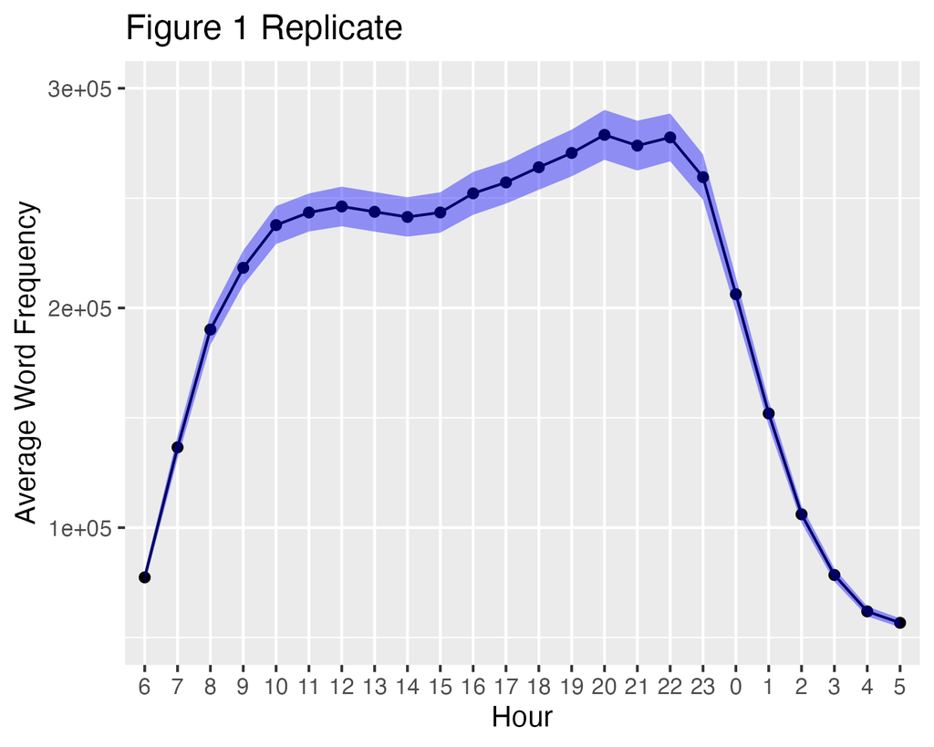

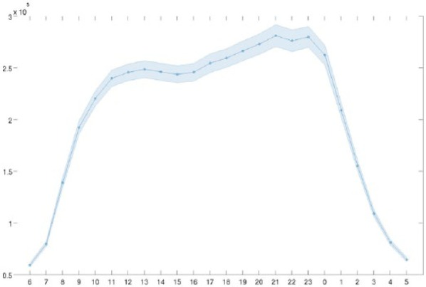

```r
# Let's generate the plot
fig.1 <- ggplot(d.Avg, aes(x = x, y = AvgFrequency, group = 1)) + # group = 1 needed for geom_line()
      geom_point() + # Add points
      geom_line() + # Connect the points, **need group = 1 in aes
      geom_ribbon(aes(ymin = lower_ci, ymax = upper_ci), alpha = 0.4, fill = "blue") +  # Add shaded area for confidence interval; lower_ci and upper_ci calculated above
      scale_x_discrete(labels = c("6", "7", "8", "9", "10", "11", "12", "13", "14", "15", "16", "17", "18", "19", "20", "21", "22", "23", "0", "1", "2", "3", "4", "5")) + # Manually change the x-axis labels to the correct times
      scale_y_continuous(limits = c(0.5e+05, 3e+05)) +  # Adjust y-axis limits
      labs(x = "Hour", y = "Average Word Frequency") +  # Label the axes
      ggtitle("Figure 1 Replicate")  # Add a title

# Compare generated plot with original figure
# Grab Fig 1 Url from Github
AuthorsFig1_url <- "https://github.com/kierstenbell/data-analysis-rep/blob/main/Figures/Figure%201.jpg?raw=true"

# Output plot to a temporary files in order to use knitr
plot_file <- tempfile(fileext = ".png")
ggsave(plot_file, plot = fig.1, width = 5, height = 4, dpi = 300)

# Compare my figure (top) to author's figures (bottom)
knitr::include_graphics(c(plot_file, AuthorsFig1_url))
```

#### Figure Analysis: Figure 2

This analysis is much more difficult and **can not be completed**. In all their 9,000 csv files, there is not one called “sunrise” or “bus”. Authors also do not describe what software they used or how they actually collected this data, so I am unable to attempt to glean Twitter data for these words. Authors also did not include sunrise/sunset data. In order to attempt this, I will use one of the files they have included called “sunset”. So although it will not be the same as what they have provided, it will be an attempt to mimic what they did.

I collected the data from here that included that date and time of sunset in the UK. This information is uploaded to github. Authors should have included this instead of manually having to extract it

Figures 3 - 11 are very similar. It is not clear exactly what words were considered for the plots.

```r
# Load data set titled "sunset", where `sunset' was extracted based on the Linguistic Inquiry and Word Count.
f <- "https://raw.githubusercontent.com/kierstenbell/data-analysis-rep/main/data/sunset.csv"
d_sunset <- read.csv(f, sep = " ")
colnames(d_sunset) <- c("date", "time", "wordfreq") #creating column names to make data easier to work with

# Check to make sure data looks ok
# Note: certain hours are missing - this indicates that the word "sunset" was not tweeted
head(d_sunset)
```

```
##         date     time wordfreq
## 1 01-01-2010 01:00:00        1
## 2 01-01-2010 05:00:00        2
## 3 01-01-2010 07:00:00        1
## 4 01-01-2010 08:00:00        2
## 5 01-01-2010 09:00:00        1
## 6 01-01-2010 10:00:00        1
```

```r
# Preprocess the data
# as.POSIXct converts character class to the POSIXlt class which allows manipulation of date/time
# This will allow us to easily extract hour, month, and year data
d_sunset$date_time <- as.POSIXct(paste(d_sunset$date, d_sunset$time), format = "%d-%m-%Y %H:%M:%OS")
d_sunset$hour_of_day <- as.numeric(format(d_sunset$date_time, "%H"))
d_sunset$month <- as.numeric(format(d_sunset$date_time, "%m"))
d_sunset$year <- as.character(format(d_sunset$date_time, "%Y"))

# if we skim this data set, we will see that we have different classes
skim(d_sunset)
```

Data summary

| Name | d_sunset |
| --- | --- |
| Number of rows | 24907 |
| Number of columns | 7 |
| _______________________ |  |
| Column type frequency: |  |
| character | 3 |
| numeric | 3 |
| POSIXct | 1 |
| ________________________ |  |
| Group variables | None |

**Variable type: character**

[output not shown]

**Variable type: numeric**

| skim_variable | n_missing | complete_rate | mean | sd | p0 | p25 | p50 | p75 | p100 | hist |
| --- | --- | --- | --- | --- | --- | --- | --- | --- | --- | --- |
| wordfreq | 0 | 1 | 3.24 | 4.16 | 1 | 1 | 2 | 4 | 171 | ▇▁▁▁▁ |
| hour_of_day | 2 | 1 | 12.20 | 6.87 | 0 | 7 | 12 | 18 | 23 | ▆▇▆▇▇ |
| month | 2 | 1 | 6.59 | 3.29 | 1 | 4 | 7 | 9 | 12 | ▇▆▆▆▇ |

**Variable type: POSIXct**

| skim_variable | n_missing | complete_rate | min | max | median | n_unique |
| --- | --- | --- | --- | --- | --- | --- |
| date_time | 2 | 1 | 2010-01-01 01:00:00 | 2014-10-31 23:00:00 | 2011-11-30 13:00:00 | 24905 |

```r
# Average the data across the 4 years
# Since we are averaging across the years, but needed to keep month and hour, use aggregate() instead of groupby()
d_sunset.Avg <- aggregate(x=d_sunset$wordfreq,
                          by=list(d_sunset$hour_of_day,d_sunset$month), FUN=mean)

colnames(d_sunset.Avg) <- c("hour", "month", "wordfreq")
head(d_sunset.Avg)
```

```
##   hour month wordfreq
## 1    0     1 1.861538
## 2    1     1 1.910448
## 3    2     1 1.555556
## 4    3     1 1.627907
## 5    4     1 1.466667
## 6    5     1 1.400000
```

```r
# Create a matrix with hours of the day as columns (0 - 23) and months (1-12) as rows
sunset_df <- dcast(d_sunset.Avg, month ~ hour, value.var = "wordfreq")
sunset_matrix <- as.matrix(sunset_df) # matrix needed for heatmap in ggplot
sunset <- melt(sunset_matrix) # needed for heatmap in ggplot
head(sunset) # checking to make sure there are correct values
```

```
##   Var1  Var2 value
## 1    1 month     1
## 2    2 month     2
## 3    3 month     3
## 4    4 month     4
## 5    5 month     5
## 6    6 month     6
```

```r
# Created my own csv sheet with sunset times in London, UK from 01-01-2010 - 31-10-2014
# Load data set titled "SunsetTimes"
g <- "https://raw.githubusercontent.com/kierstenbell/data-analysis-rep/main/data/SunsetTimes.csv"
d_sunset.times <- read_csv(g, col_names = TRUE)
head(d_sunset.times)
```

```
## # A tibble: 6 × 2
##   Date       Sunset
##   <date>     <time>
## 1 2010-01-01 16:02
## 2 2010-01-02 16:03
## 3 2010-01-03 16:04
## 4 2010-01-04 16:05
## 5 2010-01-05 16:06
## 6 2010-01-06 16:07
```

```r
# Process data by converting characters to as.posixct so we can average the time
d_sunset.times$date_time <- as.POSIXct(paste(d_sunset.times$Date, d_sunset.times$Sunset), format = "%Y-%m-%d %H:%M")

# Extract only the time ; if change to as.numeric throws an error
d_sunset.times$time <- format(d_sunset.times$date_time, format="%H:%M:%S")

# Extract month
d_sunset.times$month <- as.character(format(d_sunset.times$date_time, "%m"))

# Extract year
d_sunset.times$year <- as.character(format(d_sunset.times$date_time, "%Y"))

# Get average sunset time
library(chron)
d_sunset.times.average <- d_sunset.times %>%
  group_by(month) %>%
  reframe(AvgSunSet = mean(chron::times(time)))
d_sunset.times.average
```

```
## # A tibble: 12 × 2
##    month AvgSunSet
##    <chr> <times>
##  1 01    16:22:36
##  2 02    17:13:53
##  3 03    18:13:27
##  4 04    19:57:24
##  5 05    20:46:10
##  6 06    21:17:20
##  7 07    21:08:05
##  8 08    20:19:47
##  9 09    19:13:24
## 10 10    17:58:21
## 11 11    16:11:30
## 12 12    15:53:29
```

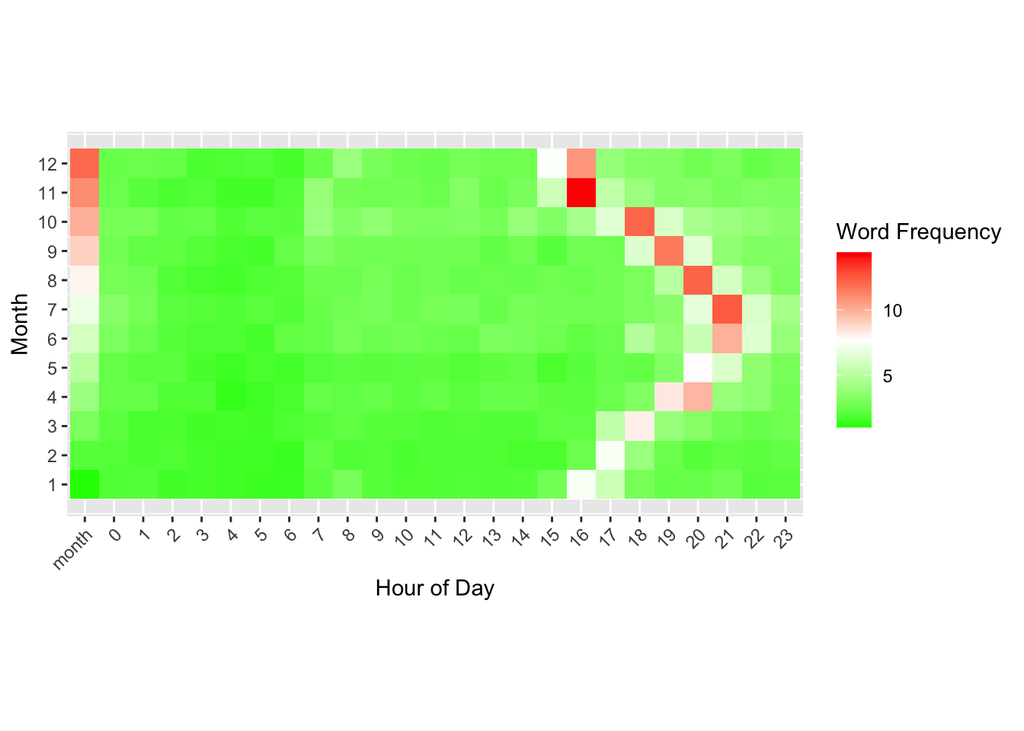

```r
# I cannot figure out how to convert the <time> variable to a <numeric> one
# used timediff() as.positx() etc. I will just hardcode the tibble for now...
# decimals were determined by dividing the minutes by 60; so 16:22 = 16 + 22/60= 16.37
month <- 1:12
AvgSunSet <- c(16.37, 17.22, 18.22, 19.95, 20.77, 21.28, 21.13, 20.31, 19.22, 17.97, 16.18, 15.88)
AvgSunSetTimes <- data.frame(month, AvgSunSet)

# Perform cubic interpolation
# Authors state they want "cubic interpolation" with 7 interpolated points, which would be a spline
# Authors had  interpolated points between each sample value so xout = 7
# this does not work, nor does ggplot accept this
#interpolated_data <- apply(word_freq_matrix[, -1], 1, function(x) {
#  na.approx(x, xout = 7, rule = 2, method = "cubic", ties="ordered")  # specify the ties argument
# })

# Create a heatmap, adding geom_point() with sunset data did nothing
heatmap <- ggplot(data = sunset, aes(x = Var2, y = Var1, fill = value)) +
                  geom_tile() +
                  scale_fill_gradientn(colours = c("green", "white", "red")) +
                  coord_fixed(ratio = 1) +  # Adjust ratio_value to lengthen the plot
                  labs(x = "Hour of Day", y = "Month", fill = "Word Frequency") +
                  scale_y_continuous(breaks = seq(1, 12, by = 1)) +
                  theme(axis.text.x = element_text(angle = 45, hjust = 1))
heatmap
```

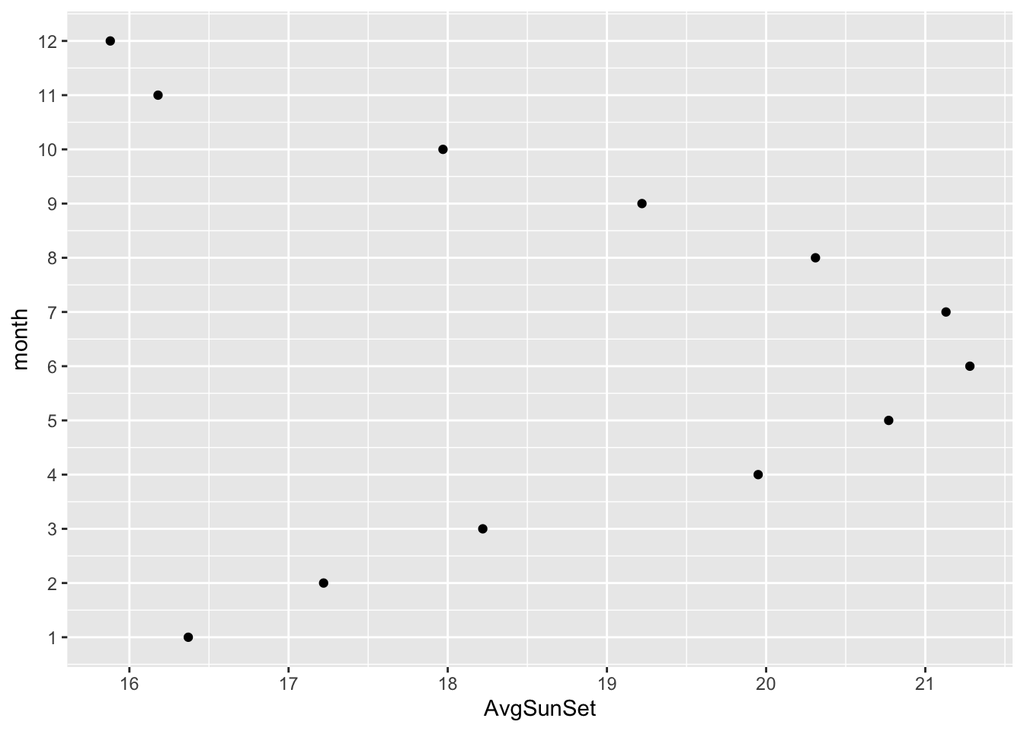

```r
# Sunset data
sunset <- ggplot(data = AvgSunSetTimes, aes(x = AvgSunSet, y = month, group = 1), color = "black", size = 100) +
          geom_point() +
         # geom_line() + this connects points based on the x-values, not y values...
          xlim(0, 23) +
          scale_x_continuous(breaks = seq(0, 23, by = 1)) +
          scale_y_continuous(breaks = seq(1, 12, by = 1))
sunset
```

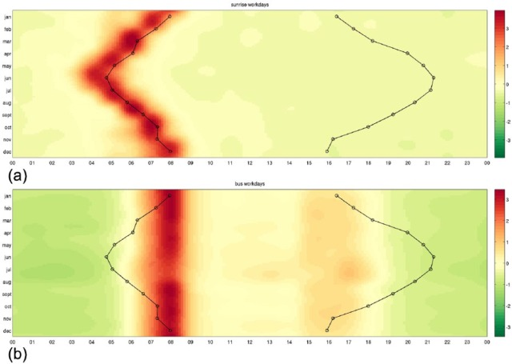

```r
## Hypothetically these should be overlaid, but errors are thrown. However, you can see that the pattern in the heatmap reflects the timing of the sunset. Although the authors show "sunrise" and "bus", we see that the same pattern emerges with "sunset"! Note: author's month scale is switched

# Compare generated plot with original figure
# Grab Fig 2 Url from Github
# Compare my figure (top) to author's figures (bottom)
knitr::include_graphics("https://github.com/kierstenbell/data-analysis-rep/blob/main/Figures/Figure%202.jpg?raw=true")
```

### Reflection

This assignment was incredibly difficult. Although this paper was a lot easier to handle than the Hughey and Buttes paper, it was still quite the challenge. The authors made *most of their data available, despite making it seem like all of their data was. They should’ve included data like sunrise/sunset times (which I manually collected), as well as the data sets for “bus” and “sunrise” for which they plotted. In general, the authors of this paper should have included a lot more information about their specific data sets. I was not able to replicate Figures 3-11 (not shown) as I was not sure what csv files were categorized as which moods. Considering that their data was already in a supplemental file, it is odd to me that they didn’t include this information. Additionally, it would’ve been helpful (for me) if the authors included some descriptive statistics for Figure 1 so that I knew whether or not my replication was correct.

For the Figures that were not shown, the authors completed analysis that I did not understand. While I am familiar with sine fitting, I struggled to figure out how to interpolate cubic plots with 7 sample points. I would need more training in statistics and circadian mathematics before I would be able to reconstruct those plots properly.

Lastly, even if I did have the “sunrise”/“bus” data set for Figure 2, I would not able to replicate Figure because I could not figure out how to include the contour lines on top of the heatmap. I received a variety of errors, and I would need to spend additional time to finally be able to include the sunset/sunrise times on the heatmaps of specific words.

Overall, I have a lot more appreciation for circadian rhythm researchers. The data wrangling and statistical analysis are not easy.